# Data Visualization using ggplot2 and dplyr in R

## Data Visualization using ggplot2 and dplyr in R

## Task One: Import packages & dataset

## In this task, we will load the required package and dataset

## into the R workspace. Also, we will explore the dataset

## 1.1: Load the required packages

library(gapminder) library(dplyr) library(ggplot2) gapminder ## 1.2: Look at the gapminder dataset gapminder ## 1.3: Create a subset of gapminder data set. ## Create gapminder_1957 gapminder_1957<- gapminder %>% filter(year==1957) gapminder_1957

## Task Two: Scatterplots

## In this task, we will use dplyr to manipulate

## the data set and plot a scatterplot using ggplot2

## 2.1: Plot a scatterplot pop on the x-axis and lifeExp on the y-axis

```
## # A tibble: 142 x 6
##    country     continent  year lifeExp      pop gdpPercap
##    <fct>       <fct>     <int>   <dbl>    <int>     <dbl>
##  1 Afghanistan Asia       1957    30.3  9240934      821.
##  2 Albania     Europe     1957    59.3  1476505     1942.
##  3 Algeria     Africa     1957    45.7 10270856     3014.
##  4 Angola      Africa     1957    32.0  4561361     3828.
##  5 Argentina   Americas   1957    64.4 19610538     6857.
##  6 Australia   Oceania    1957    70.3  9712569    10950.
##  7 Austria     Europe     1957    67.5  6965860     8843.
##  8 Bahrain     Asia       1957    53.8   138655    11636.
##  9 Bangladesh  Asia       1957    39.3 51365468      662.
## 10 Belgium     Europe     1957    69.2  8989111     9715.
## # ... with 132 more rows
```

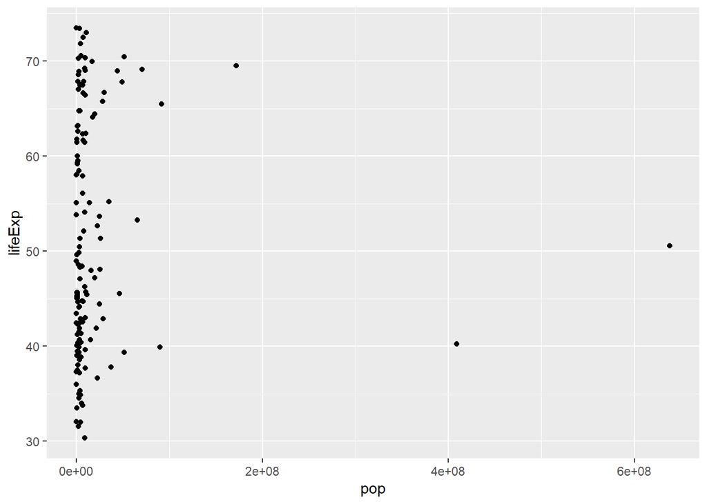

## 2.2: Change to put pop on the x-axis and gdpPercap on the y-axis

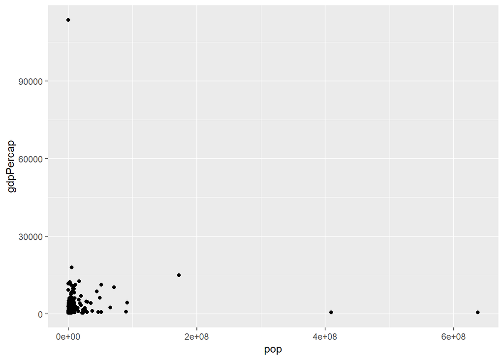

## 2.3 (Ex.): Create a scatter plot with gdpPercap on the x-axis ## and lifeExp on the y-axis

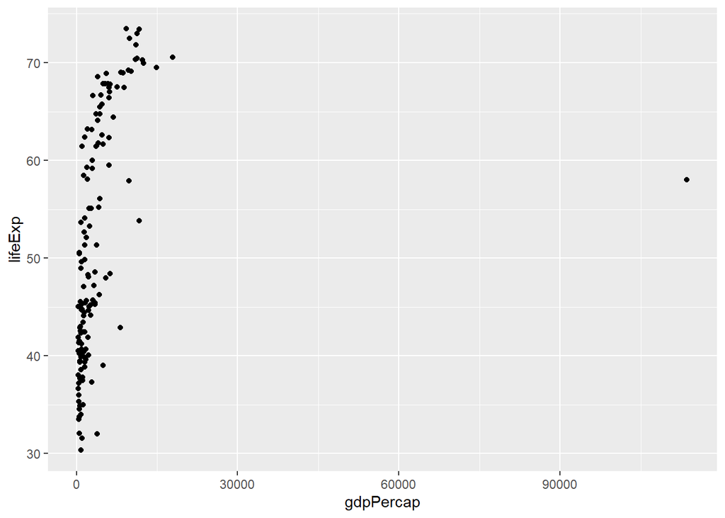

## Adding log Scales

## 2.4: Change this plot to put the x-axis on a log scale

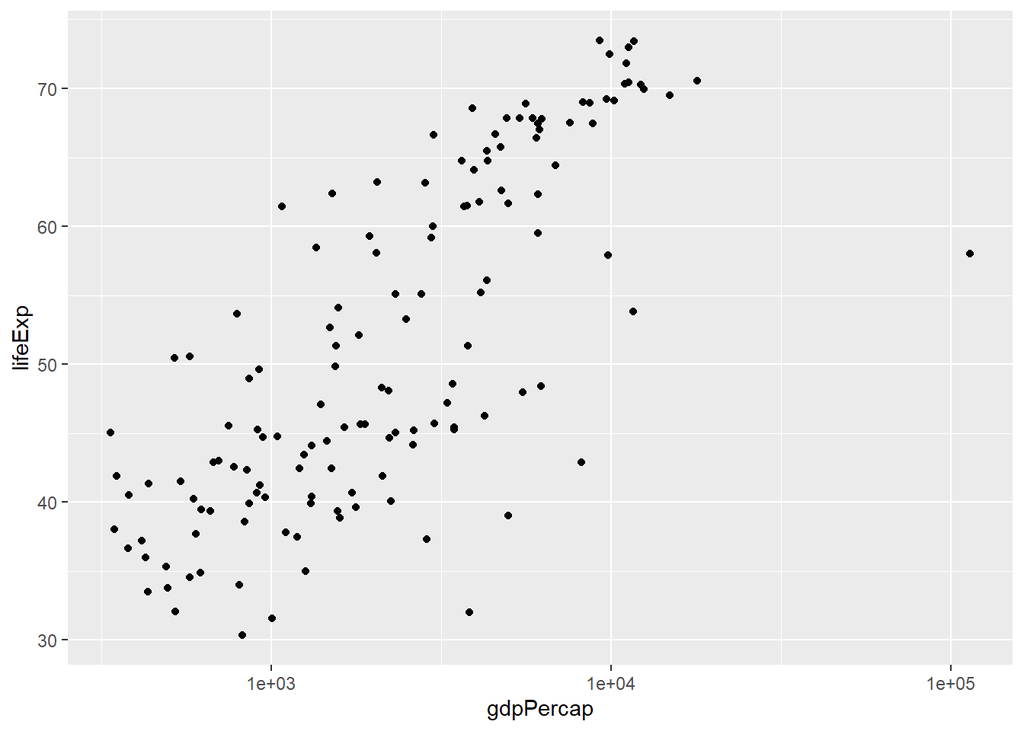

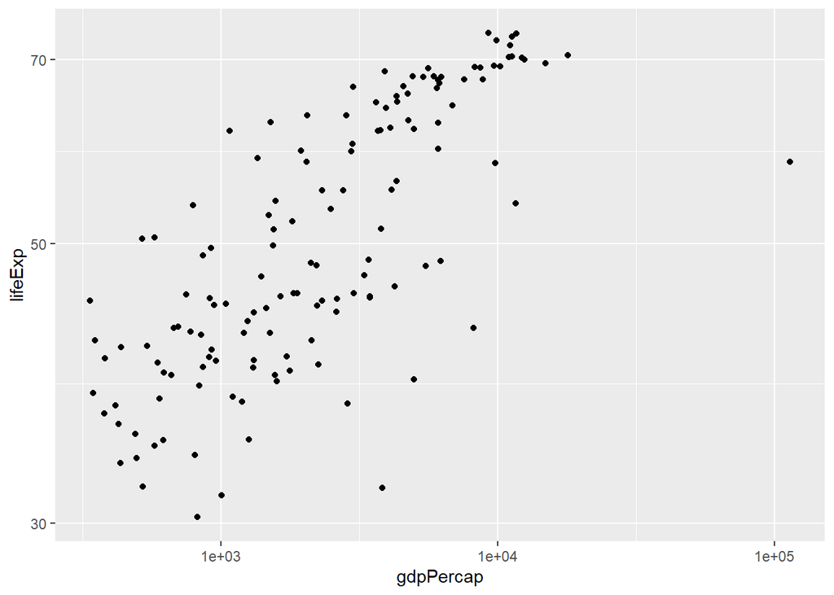

########################################################### ## Task Three: Additional Aesthetics: Color & Size Aesthetics ## In this task, we will add additional aesthetics like ## color and size to the scatterplot ###########################################################